# Тест Марковиц

Doynikov A.N.

2023-11-05

## Подготовка данных

Первую часть теста удобнее провести на Python Здесь приведу часть кода на Python для получения данных остальное допишите сами.

- Импорт исторических цен закрытия проводятся из пакета yfinance

import pandas as pd

import yfinance as yf

import time

- Зададим дату начала импорта 2022-01-01 и список тикеров акций варианта.

```python
import pandas as pd
import yfinance as yf
start_day = '2022-01-01'
assetList = ['IBM','AAPL','A','ATI','AXP','ADBE','ACB']
```

- Исторические ежедневные цены закрытия для одного тикера можно получить методом

```python
def get_One_Asset(company,start_day):
    df = pd.DataFrame()

    returns = yf.Ticker(company)

    data = returns.history(period="1y",start=start_day)

    df.index=data.index

    df[company]=data.Close

    return df
```

- Соберите данные по всем тикерам в одну переменную data типа pd.DataFrame() c помощью оператора pd.concat()

```python
data = pd.DataFrame()
for company in assetList:
    asset = get_One_Asset(company,start_day)
    data = pd.concat([data,asset],axis = 1)
```

- Сохраните данные в csv файл

```python
filename = 'myData.csv'
data.to_csv(filename, index=True)
```

## Построение оптимального по Марковитцу портфеля

Считаваем импортированные данные

```r
data <- read.csv('myData.csv',header = TRUE)
head(data)
```

```
##         Date      IBM     AAPL        A   ATI      AXP   ADBE  ACB
## 1 2021-12-31 121.3191 175.7953 157.5212 15.93 159.1514 567.06 5.41
## 2 2022-01-03 123.4793 180.1910 154.5968 16.28 163.6361 564.37 5.75
## 3 2022-01-04 125.2765 177.9040 149.3705 16.78 168.8892 554.00 5.77
## 4 2022-01-05 125.4580 173.1718 146.8117 17.25 167.0896 514.43 5.45
## 5 2022-01-06 122.8439 170.2810 147.3254 17.75 168.6207 514.12 5.37
## 6 2022-01-07 122.3810 170.4493 143.4032 18.26 170.0641 510.70 5.51
```

```r
tail(data)
```

```
##           Date      IBM   AAPL      A   ATI    AXP   ADBE   ACB
## 463 2023-11-02 145.3614 177.57 104.47 40.65 150.85 558.71 0.466
## 464 2023-11-03 146.2415 176.65 109.02 41.70 152.76 563.66 0.490
## 465 2023-11-06 147.2995 179.23 107.53 42.43 152.99 565.45 0.472
## 466 2023-11-07 147.1610 181.82 110.54 42.52 152.98 585.20 0.475
## 467 2023-11-08 146.3700 182.89 109.39 43.35 153.01 585.31 0.469
## 468 2023-11-09 146.6200 182.41 107.74 42.66 152.37 577.74 0.445
```

```r
(nAsset <- dim(data)[2])
```

```
## [1] 8
```

```r
(nDays <- dim(data)[1])
```

```
## [1] 468
```

Переводим первый столбец из строки в переменную типа `Date`

```r
Dates <- data[,1]
Dates <- as.Date(Dates, "%Y-%m-%d")
head(Dates)
```

```
## [1] "2021-12-31" "2022-01-03" "2022-01-04" "2022-01-05" "2022-01-06"
## [6] "2022-01-07"
```

Убираем первый столбец c датами остальные переводим в тип xts( time series).

```r
histData <- data[2:nAsset]
sample.xts <- as.xts(histData, order.by = Dates)
head(sample.xts)
```

```
##                 IBM     AAPL        A   ATI      AXP   ADBE  ACB
## 2021-12-31 121.3191 175.7953 157.5212 15.93 159.1514 567.06 5.41
## 2022-01-03 123.4793 180.1910 154.5968 16.28 163.6361 564.37 5.75
## 2022-01-04 125.2765 177.9040 149.3705 16.78 168.8892 554.00 5.77
## 2022-01-05 125.4580 173.1718 146.8117 17.25 167.0896 514.43 5.45
## 2022-01-06 122.8439 170.2810 147.3254 17.75 168.6207 514.12 5.37
## 2022-01-07 122.3810 170.4493 143.4032 18.26 170.0641 510.70 5.51
```

Выделим 30 последних дат на проверку результата, а первые nDays-30 оставим на построение портфеля

```r
 Lag <- 30
 (testData <- sample.xts[(nDays-Lag):nDays,])
```

```
##                 IBM   AAPL        A   ATI      AXP   ADBE   ACB
## 2023-09-28 139.9923 170.69 111.7746 42.09 149.6153 504.67 0.597
## 2023-09-29 138.7267 171.21 111.5950 41.15 148.5795 509.90 0.585
## 2023-10-02 139.2211 173.75 110.9000 40.88 148.8683 521.13 0.560
## 2023-10-03 138.8157 172.40 110.2600 40.66 144.4565 507.03 0.537
## 2023-10-04 139.4881 173.66 111.6700 40.15 146.0300 518.42 0.553
## 2023-10-05 139.9330 174.91 110.3500 39.63 147.0900 516.44 0.567
## 2023-10-06 140.4373 177.49 110.6400 39.55 149.3200 526.68 0.567
## 2023-10-09 140.6054 178.99 111.2800 39.97 148.8200 529.29 0.535
## 2023-10-10 140.5164 178.39 113.2900 40.78 150.9300 532.72 0.547
## 2023-10-11 141.6238 179.80 113.3800 41.22 151.5100 549.91 0.530
## 2023-10-12 139.6561 180.71 108.9400 39.60 151.2800 559.63 0.502
## 2023-10-13 136.9073 178.85 110.5100 37.48 151.1000 548.76 0.504
## 2023-10-16 137.6489 178.72 111.5000 37.63 152.7900 550.74 0.516
## 2023-10-17 138.7465 177.15 112.4000 38.61 154.3900 560.09 0.519
## 2023-10-18 138.4004 175.84 108.6100 38.06 151.5300 557.87 0.480
## 2023-10-19 136.4624 175.46 109.5100 36.45 149.6200 555.74 0.460
## 2023-10-20 135.6219 172.88 109.2300 35.58 141.5700 540.96 0.446
## 2023-10-23 134.8506 173.00 109.3400 36.18 144.5900 540.41 0.424
## 2023-10-24 136.2448 173.44 105.6400 36.57 144.4200 539.56 0.470
## 2023-10-25 135.5428 171.10 103.4000 36.49 143.5200 521.14 0.426
## 2023-10-26 142.1479 166.89 104.3100 37.71 143.3400 514.28 0.421
## 2023-10-27 140.9218 168.22 102.7700 37.59 141.3100 508.12 0.436
## 2023-10-30 141.0306 170.29 101.1700 37.67 143.2700 526.94 0.438
## 2023-10-31 143.0180 170.77 103.3700 37.77 146.0300 532.06 0.441
## 2023-11-01 143.7695 173.97 102.8600 37.33 146.4500 544.50 0.453
## 2023-11-02 145.3614 177.57 104.4700 40.65 150.8500 558.71 0.466
## 2023-11-03 146.2415 176.65 109.0200 41.70 152.7600 563.66 0.490
## 2023-11-06 147.2995 179.23 107.5300 42.43 152.9900 565.45 0.472
## 2023-11-07 147.1610 181.82 110.5400 42.52 152.9800 585.20 0.475
## 2023-11-08 146.3700 182.89 109.3900 43.35 153.0100 585.31 0.469
## 2023-11-09 146.6200 182.41 107.7400 42.66 152.3700 577.74 0.445
```

```r
 sample.xts <- sample.xts[1:(nDays-Lag),]
 tail(sample.xts)
```

```
##                 IBM   AAPL        A   ATI      AXP   ADBE   ACB
## 2023-09-21 145.7273 173.93 109.5092 41.71 154.0770 513.88 0.738
## 2023-09-22 145.2626 174.79 111.1858 42.20 152.4536 512.90 0.751
## 2023-09-25 144.8374 176.08 111.7148 42.32 152.6030 511.60 0.743
## 2023-09-26 141.6337 171.96 110.5072 41.27 150.5016 506.30 0.703
## 2023-09-27 141.5645 170.43 110.2777 41.33 149.2866 502.60 0.667
## 2023-09-28 139.9923 170.69 111.7746 42.09 149.6153 504.67 0.597
```

```r
  nDays <- nDays - Lag
```

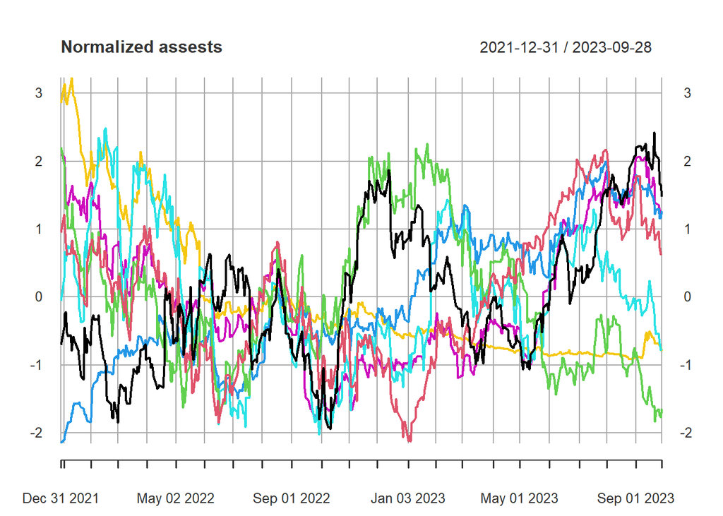

```r
std_data <- scale(sample.xts)
plot(std_data,lty=1,main='Normalized assests',type = "l")
```

```r
stock.returns <- returns(sample.xts,method = 'discrete')
head(stock.returns)
```

```
##                     IBM          AAPL            A        ATI          AXP
## 2022-01-03           NA            NA           NA         NA           NA
## 2022-01-03  0.017806144  0.0250041577 -0.018564979 0.02197115  0.028178504
## 2022-01-04  0.014554753 -0.0126916812 -0.033806122 0.03071253  0.032102502
## 2022-01-05  0.001449004 -0.0265997800 -0.017130711 0.02800949 -0.010655814
## 2022-01-06 -0.020836430 -0.0166933812  0.003499265 0.02898551  0.009163516
## 2022-01-07 -0.003768244  0.0009883923 -0.026622878 0.02873241  0.008559981
##                    ADBE          ACB
## 2022-01-03           NA           NA
## 2022-01-03 -0.004743770  0.062846610
## 2022-01-04 -0.018374462  0.003478258
## 2022-01-05 -0.071426006 -0.055459302
## 2022-01-06 -0.000602604 -0.014678886
## 2022-01-07 -0.006652110  0.026070828
```

Убираем первую строку

```r
stock.returns<-stock.returns[2:nDays,]
head(stock.returns)
```

```
##                     IBM          AAPL             A        ATI          AXP
## 2022-01-03  0.017806144  0.0250041577 -1.856498e-02 0.02197115  0.028178504
## 2022-01-04  0.014554753 -0.0126916812 -3.380612e-02 0.03071253  0.032102502
## 2022-01-05  0.001449004 -0.0265997800 -1.713071e-02 0.02800949 -0.010655814
## 2022-01-06 -0.020836430 -0.0166933812  3.499265e-03 0.02898551  0.009163516
## 2022-01-07 -0.003768244  0.0009883923 -2.662288e-02 0.02873241  0.008559981
## 2022-01-10  0.001483412  0.0001161087  6.895033e-05 0.00602413 -0.003670240
##                    ADBE          ACB
## 2022-01-03 -0.004743770  0.062846610
## 2022-01-04 -0.018374462  0.003478258
## 2022-01-05 -0.071426006 -0.055459302
## 2022-01-06 -0.000602604 -0.014678886
## 2022-01-07 -0.006652110  0.026070828
## 2022-01-10  0.029626012  0.045372049
```

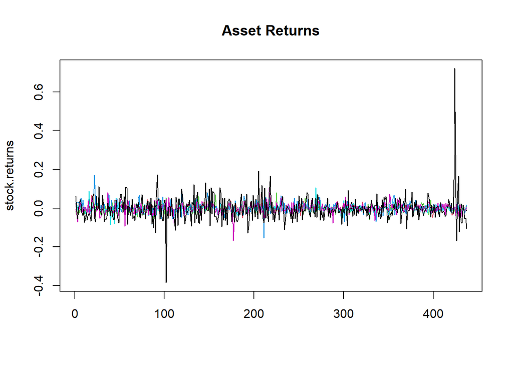

```r
matplot(stock.returns,lty=1,main='Asset Returns',type = "l")
```

Считаем ковариационную матрицу доходностей

(Skipped Code)

```
##               IBM         AAPL            A          ATI          AXP
## IBM  1.720935e-04 0.0001072657 9.569518e-05 0.0001056461 0.0001176915
## AAPL 1.072657e-04 0.0003711847 2.082578e-04 0.0001953440 0.0002292908
## A    9.569518e-05 0.0002082578 3.908758e-04 0.0001784097 0.0001785152
## ATI  1.056461e-04 0.0001953440 1.784097e-04 0.0007373466 0.0002357333
## AXP  1.176915e-04 0.0002292908 1.785152e-04 0.0002357333 0.0004116321
## ADBE 1.142316e-04 0.0003255975 2.681101e-04 0.0001753612 0.0002455328
## ACB  1.309963e-04 0.0004156807 2.804183e-04 0.0003468348 0.0004015480
##              ADBE          ACB
## IBM  0.0001142316 0.0001309963
## AAPL 0.0003255975 0.0004156807
## A    0.0002681101 0.0002804183
## ATI  0.0001753612 0.0003468348
## AXP  0.0002455328 0.0004015480
## ADBE 0.0006491744 0.0004551728
## ACB  0.0004551728 0.0041930827
```

Зададим матрицу `Amat` и вектор `bvec` ограничений. Вектор столбец решений $d$ должен удовлетворять ограничениям вида $d^T Amat[,k] \ge bvec[k];k=1,...,meq+mge$

где:

$Amat[,k]$ - $k$-й вектор столбец матрицы `Amat`;

$bvec[k]$ - $k$-й элемент вектора `bvec`;

$meq$ - количество ограничений в виде точного равенства;

$mge$ - количество ограничений в виде неравенства $\ge$.

Точное описание устройства матрицы `Amat` дано в лекции.

(Skipped Code)

Разрешим как длинные, так и короткие позиции. Зададим ограничение на максимальную долю размешения в случае возможного наличия коротких позиций процент размещения будет таким $b_i \ge -0.45$, а в случае если разрешены только длинные позиций ограничения будут такие $0 \le b_i \le 0.45$.

```r
max.allocation <- 0.45
bvec <- c(bvec, rep(-max.allocation, n))
bvec
```

```
## [1]  1.00 -0.45 -0.45 -0.45 -0.45 -0.45 -0.45 -0.45
```

Зададим максимальную доходность и шаг изменения доходности и определим количество итераций цикла по доходности.

```r
  risk.premium.up <-0.5
  risk.increment <- 0.01
  (loops <- risk.premium.up / risk.increment + 1)
```

```
## [1] 51
```

```r
  loop <- 1
```

Инициализируем матрицу, где будем хранить оптимальные портфели и различные статистики

```r
  eff <- matrix(nrow=loops, ncol=n+3)
  colnames(eff) <- c(colnames(stock.returns), "Std.Dev", "Exp.Return", "sharpe")
```

Получаем оптимальный портфель, доходность, стандартное отклонение и коэффициент Шарпа на каждой итерации

(Skipped Code)

```
##    IBM      AAPL          A        ATI        AXP         ADBE         ACB
## 1 0.45 0.1849828 0.21501554 0.06294947 0.12757180 -0.023883304 -0.01663633
## 2 0.45 0.1885581 0.17655577 0.10954204 0.11471036 -0.013318671 -0.02604756
## 3 0.45 0.1921333 0.13809599 0.15613462 0.10184892 -0.002754038 -0.03545878
## 4 0.45 0.1957085 0.09963621 0.20272720 0.08898748  0.007810594 -0.04487000
## 5 0.45 0.1992837 0.06117643 0.24931978 0.07612604  0.018375227 -0.05428122
## 6 0.45 0.2028590 0.02271666 0.29591236 0.06326459  0.028939860 -0.06369245
##      Std.Dev   Exp.Return     sharpe
## 1 0.01281755 0.0003018543 0.02355007
## 2 0.01288475 0.0004745656 0.03683157
## 3 0.01308427 0.0006472769 0.04946985
## 4 0.01341021 0.0008199882 0.06114656
## 5 0.01385365 0.0009926995 0.07165619
## 6 0.01440373 0.0011654108 0.08091033
```

Определяем точку на , где коэффициент Шарпа максимален

(Skipped Code)

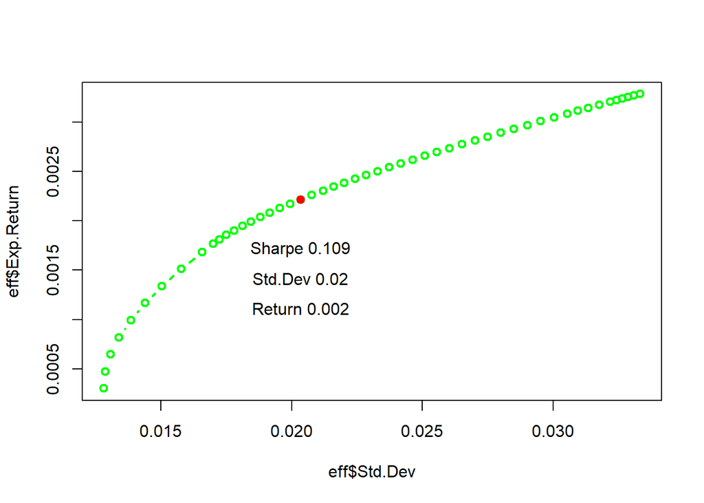

Оптимальный портфель по Марковитцу

```r
eff.optimal.point
```

```
##     IBM      AAPL          A  ATI       AXP      ADBE        ACB    Std.Dev
## 20 0.45 0.4096237 -0.3673249 0.45 0.1188027 0.1281209 -0.1892224 0.02035237
##    Exp.Return    sharpe
## 20 0.00221538 0.1088512
```

Предположим у Вас 1000000 долларов Разделим его на доли вложения в каждый актив. Для этого нормируем оптимальный портфель так, чтобы сумма модулей была равна 1.

```r
   eff.optimal.point<-eff.optimal.point[1:7]
   sabs <- sum(abs(eff.optimal.point))
   norm_eff.optimal.point <- eff.optimal.point/sabs
   sum(abs(norm_eff.optimal.point))
```

```
## [1] 1
```

Поделим весь капитал на долю вложения на каждый актив

```r
N <- 1000000
(d_money <- norm_eff.optimal.point*N)
```

```
##         IBM     AAPL         A      ATI      AXP     ADBE       ACB
## 20 212957.8 193850.1 -173832.7 212957.8 56222.14 60631.88 -89547.52
```

В итоге портфель на следующий интервал времени в количестве акций на последний день тренировочной выборки

```r
nData <- dim(sample.xts)[1]
(portfolio <- as.integer (d_money/ histData[nData,]))
```

```
## [1]    1521    1135   -1555    5059     375     120 -149995
```

Его стоимость на момент создания с учетом округлений

```r
sum(abs(portfolio)*histData[nData,])
```

```
## [1] 999617.5
```

Посмотрим на стоимость нашего портфеля по тестовым 30 дням

```r
res <- rep(0,Lag)
for (i in 1 :Lag)
{
  change <- histData[nData+i,]-histData[nData,]
  res[i]<-sum(portfolio*change)
  print(paste(Dates[nData+i],' ',res[i]))
}
```

```
## [1] "2023-09-29   -3771.8038842082"
## [1] "2023-10-02   4783.6370472312"
## [1] "2023-10-03   2620.39830988646"
## [1] "2023-10-04   -142.465752482414"
## [1] "2023-10-05   -565.069316446781"
## [1] "2023-10-06   4339.62664455175"
## [1] "2023-10-09   12352.9138551354"
## [1] "2023-10-10   11911.6875142455"
## [1] "2023-10-11   22112.7005089521"
## [1] "2023-10-12   24141.323538065"
## [1] "2023-10-13   3010.94404143095"
## [1] "2023-10-16   2282.1697345376"
## [1] "2023-10-17   6999.91796523333"
## [1] "2023-10-18   12608.6062016189"
## [1] "2023-10-19   1713.11789605021"
## [1] "2023-10-20   -9151.85319361091"
## [1] "2023-10-23   -2958.00290754437"
## [1] "2023-10-24   322.933307379484"
## [1] "2023-10-25   3729.60316801071"
## [1] "2023-10-26   13613.7794142962"
## [1] "2023-10-27   11295.6997263432"
## [1] "2023-10-30   19396.7153401673"
## [1] "2023-10-31   21248.7407849133"
## [1] "2023-11-01   24441.1992552876"
## [1] "2023-11-02   46646.1626464427"
## [1] "2023-11-03   42887.5182665586"
## [1] "2023-11-06   56436.0204734802"
## [1] "2023-11-07   56856.1551629007"
## [1] "2023-11-08   63779.0656584799"
## [1] "2023-11-09   65141.0520030856"
```

Стоимость нашего портфеля по 30 тестовым дням

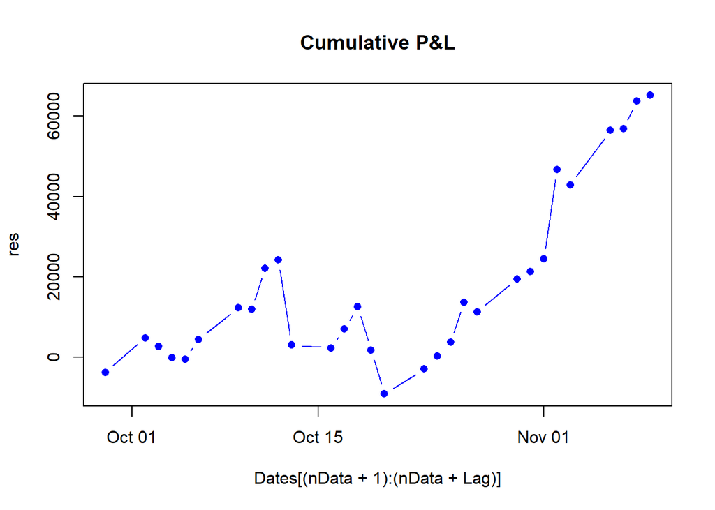

```r
  plot(Dates[(nData+1):(nData+Lag)], res,main='Cumulative P&L',type="b",col = 'blue',pch=16)
```

## Задание

Повторите вычисления для своего варианта

## Требования к отчету

Отчет должен быть сохранен в формате html с пояснениями.

Срок выполнения задания 1 неделя до следующей лекции.

Задание выполняется на языке R или Python по желанию.

Все выводы должны быть строго статистически обоснованы результатами вычислений и соответствующими текстовыми комментариями.

Ошибки исполнения можно исправить только первые 3 дня с момента выдачи задания.

Все замечания и вопросы рассматриваются только письменно в течении 1-ой недели со дня выдачи теста.

Отчет сдавать письменно в виде файла отчета в формате html по e-mail на адрес  
doynikova@mail.ru .

**Внимание!!! Компании время от времени меняют название тикера. Также их иногда могут исключить из списка S&P500 (а именно из этого списка я их выбрал). В таком случае данных по компании в yfinance не будет, просто исключите компанию из списка варианта**

Результаты выполнения теста будут опубликованы по мере выполнения. Претензии принимаются и будут рассмотрены на занятии.

### Вариант 1,14

Ticker Industry

AMZN Amazon Consumer Discretionary

ANET Arista Networks Information Technology

ANSS Ansys Information Technology

ANTM Anthem Health Care

AON Aon Financials

AOS A. O. Smith Industrials

APA APA Corporation Energy

APD Air Products & Chemicals Materials

APH Amphenol Corp Information Technology

APTV Aptiv Consumer Discretionary

ARE Alexandria Real Estate Equities Real Estate

### Вариант 2,15

Ticker Industry

AON Aon Financials

AOS A. O. Smith Industrials

APA APA Corporation Energy

APD Air Products & Chemicals Materials

APH Amphenol Corp Information Technology

APTV Aptiv Consumer Discretionary

ARE Alexandria Real Estate Equities Real Estate

ATO Atmos Energy Utilities

ATVI Activision Blizzard Communication Services

### Вариант 3,16

Ticker Industry

BA Boeing Industrials

BAC Bank of America Financials

BAX Baxter International Health Care

BBY Best Buy Consumer Discretionary

BDX Becton Dickinson Health Care

BEN Franklin Resources Financials

BIIB Biogen Health Care

BIO Bio-Rad Laboratories Health Care

BK BNY Mellon Financials

### Вариант 4,17

Ticker Industry

BKNG Booking Holdings Consumer Discretionary

BKR Baker Hughes Energy

BLK BlackRock Financials

BLL Ball Corp Materials

BMY Bristol Myers Squibb Health Care

BR Broadridge Financial Solutions Information Technology

BRO Brown & Brown Financials

BSX Boston Scientific Health Care

BWA BorgWarner Consumer Discretionary

### Вариант 5,18

Ticker Industry

BXP Boston Properties Real Estate

C Citigroup Financials

CAG Conagra Brands Consumer Staples

CAH Cardinal Health Health Care

CARR Carrier Global Industrials

CAT Caterpillar Industrials

CB Chubb Financials

CBOE Cboe Global Markets Financials

CBRE CBRE Real Estate

CCI Crown Castle Real Estate

### Вариант 6,19

Ticker Industry

CCL Carnival Corporation Consumer Discretionary

CDAY Ceridian Information Technology

CDNS Cadence Design Systems Information Technology

CDW CDW Information Technology

CE Celanese Materials

CERN Cerner Health Care

CF CF Industries Materials

CFG Citizens Financial Group Financials

CHD Church & Dwight Consumer Staples

CHRW C. H. Robinson Industrials

CHTR Charter Communications Communication Services

CI Cigna Health Care

CINF Cincinnati Financial Financials

### Вариант 7,20

Ticker Industry

CL Colgate-Palmolive Consumer Staples

CLX Clorox Consumer Staples

CMA Comerica Financials

CMCSA Comcast Communication Services

CME CME Group Financials

CMG Chipotle Mexican Grill Consumer Discretionary

CMI Cummins Industrials

CMS CMS Energy Utilities

CNC Centene Corporation Health Care

### Вариант 8,21

Ticker Industry

CNP CenterPoint Energy Utilities

COF Capital One Financial Financials

COG Cabot Oil & Gas Energy

COO The Cooper Companies Health Care

COP ConocoPhillips Energy

COST Costco Consumer Staples

CPB Campbell Soup Consumer Staples

CPRT Copart Industrials

CRL Charles River Laboratories Health Care

### Вариант 9,22

Ticker Industry

CRM Salesforce Information Technology

CSCO Cisco Systems Information Technology

CSX CSX Industrials

CTAS Cintas Corporation Industrials

CTLT Catalent Health Care

CTSH Cognizant Technology Solutions Information Technology

CTVA Corteva Materials

CTXS Citrix Systems Information Technology

CVS CVS Health Health Care

CVX Chevron Corporation Energy

### Вариант 10,23

Ticker Industry

CZR Caesars Entertainment Consumer Discretionary

D Dominion Energy Utilities

DAL Delta Air Lines Industrials

DD DuPont Materials

DE Deere & Co. Industrials

DFS Discover Financial Services Financials

DG Dollar General Consumer Discretionary

DGX Quest Diagnostics Health Care

DHI D. R. Horton Consumer Discretionary

DHR Danaher Corporation Health Care

### Вариант 11,24

Ticker Industry

DIS The Walt Disney Company Communication Services

DISCA Discovery (Series A) Communication Services

DISCK Discovery (Series C) Communication Services

DISH Dish Network Communication Services

DLR Digital Realty Trust Real Estate

DLTR Dollar Tree Consumer Discretionary

DOV Dover Corporation Industrials

DOW Dow Materials

DPZ Domino’s Pizza Consumer Discretionary

DRE Duke Realty Corp Real Estate

DRI Darden Restaurants Consumer Discretionary

### Вариант 12,25

Ticker Industry

DTE DTE Energy Utilities

DUK Duke Energy Utilities

DVA DaVita Health Care

DVN Devon Energy Energy

DXC DXC Technology Information Technology

DXCM DexCom Health Care

EA Electronic Arts Communication Services

EBAY eBay Consumer Discretionary

ECL Ecolab Materials

ED Consolidated Edison Utilities

EFX Equifax Industrials

EIX Edison International Utilities

### Вариант 13,26

EMN Eastman Chemical Materials

EMR Emerson Electric Company Industrials

ENPH Enphase Energy Information Technology

EOG EOG Resources Energy

EQIX Equinix Real Estate

EQR Equity Residential Real Estate

ES Eversource Energy Utilities

ESS Essex Property Trust Real Estate

ETN Eaton Corporation Industrials

ETR Entergy Utilities

ETSY Etsy Consumer Discretionary